# ‘Data Analysis With R’

### Creating and changing variables

To access variables within a data frame, recall that we use the `$` dollar sign operator. For example, this command takes the information in the `Height` variable (within `dat1`) and calculates the mean height.

```r
mean(dat1$Height)
```

```
## [1] 66.76069
```

We can create new variables using the `<-` operator, as before:

```r
# create a variable with height as feet, rather than inches
# - there are 12 inches in a foot

dat1$Height_feet <- dat1$Height / 12
```

To create a new variable conditional on the levels of another variable, we can use the `ifelse()` function:

```r
# if 'Height' is greater than 65 inches, make 'Height2' equal to 1
#   otherwise make 'Height2' equal to 0
dat1$Height2 <- ifelse(dat1$Height > 65, yes = 1, no = 0)
```

Confused about how to use `ifelse()`? Read the help documentation with `help("ifelse")`.

Here’s how you would accomplish the same tasks using the `dplyr` package. I strongly recommend using `dplyr` as your primary way to handle data frames. You can find good tutorials and videos online, like [this](https://cran.r-project.org/web/packages/dplyr/vignettes/dplyr.html) and [this](https://www.youtube.com/watch?v=aywFompr1F4).

```r
dat2 <- dat1 %>%
  mutate(
    Height_feet = Height / 12,
    Height2 = ifelse(Height > 65, 1, 0) )
```

### Selecting rows and columns of a data frame

The `subset()` function is for selecting particular rows and columns. Note that we test whether two objects are equal using the `==` operator, with two equality symbols.

```r
# create a data frame called 'dat3' from 'dat2' that includes
#   only the rows with male gender
dat3 <- subset(dat2, Gender == "M")

# create a data frame called 'dat4' from 'dat2' that only
#   contains the variables 'Gender' and 'Height', AND
#   keeps rows with Height > 65
dat4 <- subset(dat2, Height > 65, select = c("Gender", "Height"))
```

We can do the same thing using `dplyr` functions:

```r
dat4 <- dat2 %>%
  filter(Height > 65) %>%
  select(Gender, Height)
```

Notice how the commands are linked using the pipe operator `%>%`.

### Descriptive statistics

```r
# For categorical variables, get counts for each level
table(dat1$Gender)
```

```
##
##   F   M
## 433 465
```

```r
# Get propotions by dividing the counts by the total number of observations
table(dat1$Gender) / nrow(dat1)
```

```
##
##         F         M
## 0.4821826 0.5178174
```

Rather than using base R, we can use the `gmodels` package for getting frequencies more easily. We will use the `CrossTable()` function from the `gmodels` package.

```r
library(gmodels)
CrossTable(dat1$Gender)
```

```
##
##
##    Cell Contents
## |-------------------------|
## |                       N |
## |         N / Table Total |
## |-------------------------|
##
##
## Total Observations in Table:  898
##
##
##           |         F |         M |
##           |-----------|-----------|
##           |       433 |       465 |
##           |     0.482 |     0.518 |
##           |-----------|-----------|
##
##
##
##
```

We can get a frequency table for two variables at the same time. Recall that we created the `Height2` variable in the section “Creating and changing variables”.

```r
CrossTable(dat1$Gender, dat1$Height2)
```

```
##
##
##    Cell Contents
## |-------------------------|
## |                       N |
## | Chi-square contribution |
## |           N / Row Total |
## |           N / Col Total |
## |         N / Table Total |
## |-------------------------|
##
##
## Total Observations in Table:  898
##
##
##              | dat1$Height2
##  dat1$Gender |         0 |         1 | Row Total |
## -------------|-----------|-----------|-----------|
##            F |       301 |       132 |       433 |
##              |   120.420 |    71.653 |           |
##              |     0.695 |     0.305 |     0.482 |
##              |     0.899 |     0.234 |           |
##              |     0.335 |     0.147 |           |
## -------------|-----------|-----------|-----------|
##            M |        34 |       431 |       465 |
##              |   112.133 |    66.722 |           |
##              |     0.073 |     0.927 |     0.518 |
##              |     0.101 |     0.766 |           |
##              |     0.038 |     0.480 |           |
## -------------|-----------|-----------|-----------|
## Column Total |       335 |       563 |       898 |
##              |     0.373 |     0.627 |           |
## -------------|-----------|-----------|-----------|
##
##
```

To run a Chi-square test of whether two categorical variables are correlated, we do:

```r
chisq.test(dat1$Gender, dat1$Height2)
```

```
##
##  Pearson's Chi-squared test with Yates' continuity correction
##
## data:  dat1$Gender and dat1$Height2
## X-squared = 368.27, df = 1, p-value < 2.2e-16
```

If the p-value is less than 0.05, we say there is evidence to reject the null hypothesis that the variables are independent. If the p-value is more than 0.05, we say there is not enough evidence to reject the null hypothesis.

### Describing data with graphics

Recall that we’re using a dataset about height, which we retrieved from online:

```r
dat1 <- read.csv("http://www.math.uah.edu/stat/data/Galton.csv", as.is = TRUE)
```

To describe a single continuous variable, create a histogram with the `hist()` function:

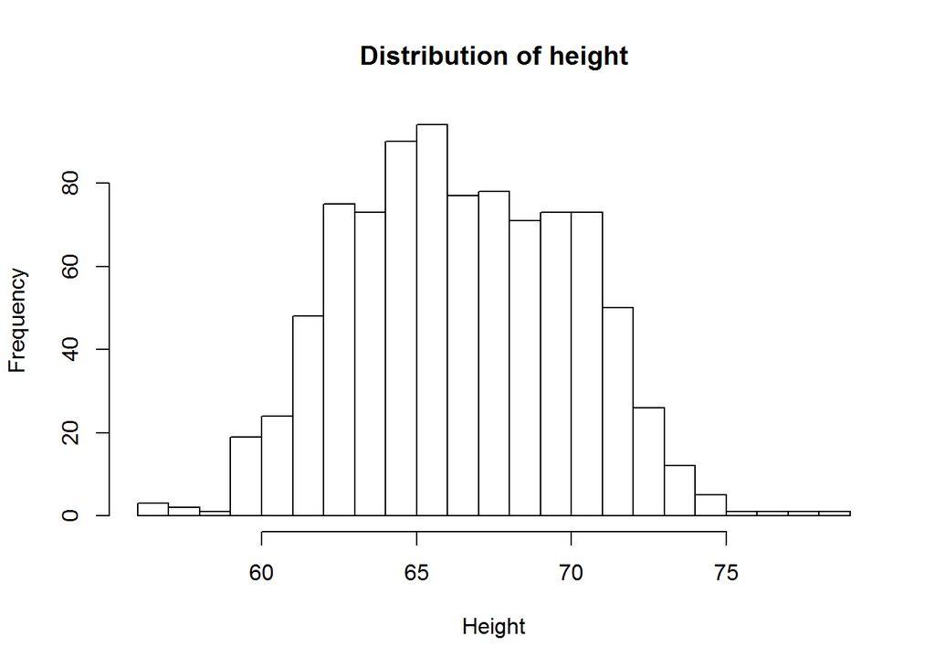

```r
hist(
  x = dat1$Height,
  breaks = 20,   # how many groups to use
  xlab = "Height",  # the label below the x-axis
  main = "Distribution of height"
)
```

To show the relationship between two continuous variables, use a scatterplot with the `plot()` function:

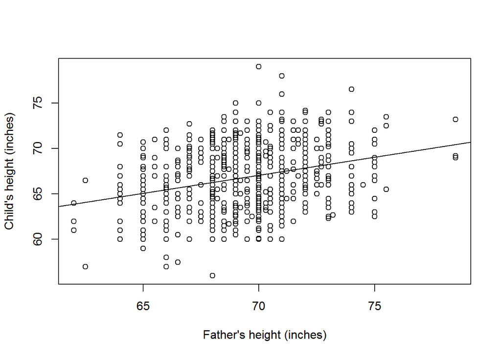

```r
plot(
  x = dat1$Father,
  y = dat1$Height,
  main = "",        # No main title
  xlab = "Father's height (inches)",
  ylab = "Child's height (inches)"
)

fit1 <- lm(Height ~ Father, data = dat1)  # fit a linear regression
abline(fit1)   # show the line of best fit on the plot
```

To show the relationship between a categorical and continuous variable, use a barplot:

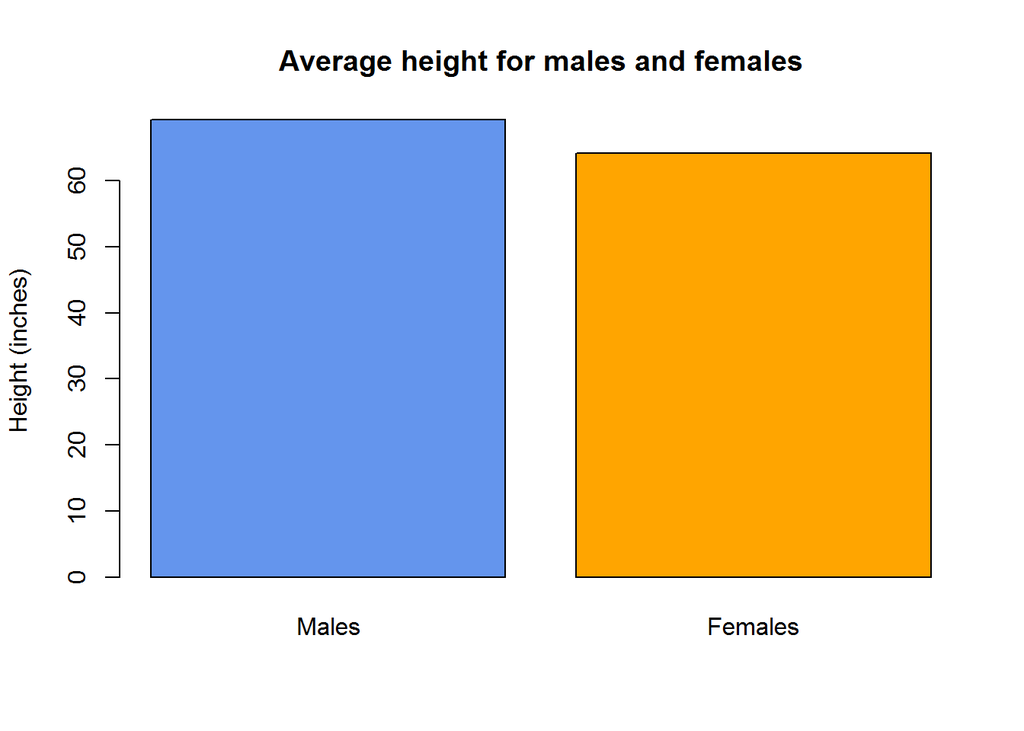

```r
mean_height_males <- mean(dat1[dat1$Gender == "M", "Height"])
mean_height_females <- mean(dat1[dat1$Gender == "F", "Height"])

barplot(
  height = c(mean_height_males, mean_height_females),
  names.arg = c("Males", "Females"),
  ylab = "Height (inches)",
  col = c("cornflowerblue", "orange"),
  main = "Average height for males and females"
)
```

These graphics are standard ways that researchers present information in scientific articles. For more advanced ways to visualize information, I recommend the `ggplot2` package. Here is a [cheat sheet](https://www.rstudio.com/wp-content/uploads/2015/03/ggplot2-cheatsheet.pdf) showing different types of visualizations you can create.

### Linear regression

Regression analysis is a way to determine whether certain factors are associated with an outcome, and to what extent. For example, we might be interested in whether a father’s height is associated with the height of his child. With regression, we can answer the following questions about the people in our data set:

- Did taller fathers tend to have taller children? (sign of the coefficient)
- If a father was 1 inch taller, how much taller would we expect his child to be? (magnitude of the coefficient)
- How improbable would this result be if there’s truly no association between father and child heights? (p-value)

Using the dataset we got from online, we can answer these questions:

```r
dat1 <- read.csv("http://www.math.uah.edu/stat/data/Galton.csv", as.is = TRUE)


fit1 <- lm(Height ~ Father, data = dat1)
summary(fit1)
```

```
##
## Call:
## lm(formula = Height ~ Father, data = dat1)
##
## Residuals:
##      Min       1Q   Median       3Q      Max
## -10.2683  -2.6689  -0.2092   2.6342  11.9329
##
## Coefficients:
##             Estimate Std. Error t value Pr(>|t|)
## (Intercept) 39.11039    3.22706  12.120   <2e-16 ***
## Father       0.39938    0.04658   8.574   <2e-16 ***
## ---
## Signif. codes:  0 '***' 0.001 '**' 0.01 '*' 0.05 '.' 0.1 ' ' 1
##
## Residual standard error: 3.446 on 896 degrees of freedom
## Multiple R-squared:  0.07582,    Adjusted R-squared:  0.07479
## F-statistic: 73.51 on 1 and 896 DF,  p-value: < 2.2e-16
```

We used the function `lm()` to run a linear regression, where `Height` (child’s height) is our outcome of interest and `Father` (father’s height) is our only predictor. In general, we specify formulas as `outcome ~ predictor1 + predictor2` if there are two predictors, for example, where the outcome variable is on the left side of the tilde `~`. We stored the results of the regression into an object called `fit1` and asked for a summary for the results.

In the column `Estimate`, we see that for each 1-inch increase in height of the father, we expect that the child’s height is 0.399 inches higher. This result is statistically significant, because the p-value (`Pr(>|t|)` column) is less than 0.05. The 3 stars indicate the level of statistical signficance. Together these results tell us *whether* a variable matters (p-value) and *how much* it affects our outcome (coefficient estimate).

We can include other predictors that we believe help us understand what makes some children shorter or taller, for example, the child’s gender and their mother’s height. I also included `Kids` (number of children in the family), a variable we do not expect to be associated with a child’s height.

```r
fit2 <- lm(Height ~ Father + Mother + Gender + Kids, data = dat1)
summary(fit2)
```

```
##
## Call:
## lm(formula = Height ~ Father + Mother + Gender + Kids, data = dat1)
##
## Residuals:
##     Min      1Q  Median      3Q     Max
## -9.4748 -1.4500  0.0889  1.4716  9.1656
##
## Coefficients:
##             Estimate Std. Error t value Pr(>|t|)
## (Intercept) 16.18771    2.79387   5.794 9.52e-09 ***
## Father       0.39831    0.02957  13.472  < 2e-16 ***
## Mother       0.32096    0.03126  10.269  < 2e-16 ***
## GenderM      5.20995    0.14422  36.125  < 2e-16 ***
## Kids        -0.04382    0.02718  -1.612    0.107
## ---
## Signif. codes:  0 '***' 0.001 '**' 0.01 '*' 0.05 '.' 0.1 ' ' 1
##
## Residual standard error: 2.152 on 893 degrees of freedom
## Multiple R-squared:  0.6407, Adjusted R-squared:  0.6391
## F-statistic: 398.1 on 4 and 893 DF,  p-value: < 2.2e-16
```

Note that the `Kids` variable has a p-value above 0.05, so it is not statistically significant.

To get *confidence intervals* around the coefficients, we use the `confint()` function.

```r
confint(fit2)
```

```
##                   2.5 %       97.5 %
## (Intercept) 10.70439872 21.671027163
## Father       0.34027752  0.456333043
## Mother       0.25961222  0.382298344
## GenderM      4.92689445  5.492999022
## Kids        -0.09716097  0.009524249
```

```r
# Coefficients and confidence intervals together
cbind(coef(fit2), confint(fit2))
```

```
##                               2.5 %       97.5 %
## (Intercept) 16.18771294 10.70439872 21.671027163
## Father       0.39830528  0.34027752  0.456333043
## Mother       0.32095528  0.25961222  0.382298344
## GenderM      5.20994674  4.92689445  5.492999022
## Kids        -0.04381836 -0.09716097  0.009524249
```

### Logistic regression

The previous section on linear regression is useful when the outcome is a continuous variable, like height. Often, however, the outcome is a yes-or-no variable. This is also known as a binary or dichotomous variable. In this case, we use logistic regression.

- Continuous outcome? Use linear regression
- Binary outcome? Use logistic regression

First, we convert the continuous `Height` variable into a binary variable, based on whether a child’s height is greater than 65.

```r
dat1$Height2 <- ifelse(dat1$Height > 65, 1, 0)
```

Then, we use a function called `glm()`, which stands for “generalized linear model”. We specify that the regression family is “binomial” to tell `glm()` that we want to do logistic regression.

```r
fit3 <- glm(
  Height2 ~ Father + Mother + Gender + Kids,
  data = dat1,
  family = "binomial"
)

summary(fit3)
```

```
##
## Call:
## glm(formula = Height2 ~ Father + Mother + Gender + Kids, family = "binomial",
##     data = dat1)
##
## Deviance Residuals:
##     Min       1Q   Median       3Q      Max
## -2.9767  -0.5920   0.2189   0.4214   2.3971
##
## Coefficients:
##              Estimate Std. Error z value Pr(>|z|)
## (Intercept) -43.35865    4.65924  -9.306  < 2e-16 ***
## Father        0.31839    0.04495   7.083 1.41e-12 ***
## Mother        0.32262    0.04720   6.835 8.22e-12 ***
## GenderM       4.13765    0.26140  15.829  < 2e-16 ***
## Kids         -0.06870    0.03656  -1.879   0.0602 .
## ---
## Signif. codes:  0 '***' 0.001 '**' 0.01 '*' 0.05 '.' 0.1 ' ' 1
##
## (Dispersion parameter for binomial family taken to be 1)
##
##     Null deviance: 1186.37  on 897  degrees of freedom
## Residual deviance:  651.08  on 893  degrees of freedom
## AIC: 661.08
##
## Number of Fisher Scoring iterations: 5
```

Interpreting the results of logistic regression are similar to linear regression in some ways.

- If the coefficient is positive, it means that a higher level of the factor is associated with a higher level of the outcome. For example, higher father’s height is associated with higher child’s height.
- If the p-value on a coefficient is less than 0.05, the factor is statistically significant.

However, the interpretation for logistic regression is also different. We need to *exponentiate* the coefficients to interpret them as *odds ratios*.

```r
odds_ratio <- exp(coef(fit3))
confidence_intervals <- exp(confint(fit3))
# Coefficients and confidence intervals together
results <- cbind(odds_ratio, confidence_intervals)
round(results, digits = 3)
```

```
##             odds_ratio  2.5 %  97.5 %
## (Intercept)      0.000  0.000   0.000
## Father           1.375  1.262   1.505
## Mother           1.381  1.261   1.518
## GenderM         62.655 38.303 106.958
## Kids             0.934  0.868   1.003
```

Regression methods are a fundamental tool for data analysts. Many resources are available for self-learning online, including this [free textbook](http://onlinestatbook.com/2/regression/intro.html).